# GAMMs in a nutshell

Michele Gubian

May 2023

# Modelling curves

Suppose we have curves belonging to two categories: NP (No Peak) and P (Peak):

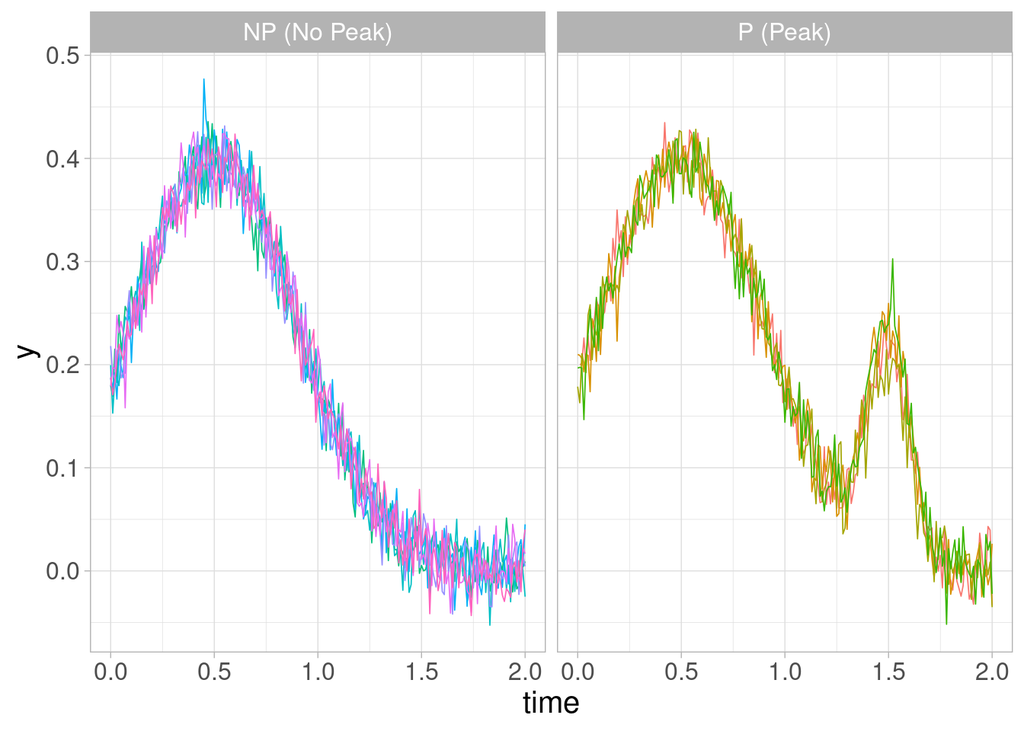

We could use some combination of linear regression and polynomial curve fitting:

$$y_i = \beta_{0, NP} + \beta_{0, P} + \beta_{1, NP} \cdot t_i + \beta_{1,
P} \cdot t_i + \beta_{2, NP} \cdot t_i^2 + \beta_{2, P} \cdot t_i^2 +
\beta_{3, NP} \cdot t_i^3 + \beta_{3, P} \cdot t_i^3 + ... + \epsilon_i$$
where $i$ is **not** an index for an entire curve, but for a single sample.

## Problems

- We don’t know where to stop with power terms
  - but we could use model selection
- Pure power series are really bad at interpolating general shapes
  - because Taylor’s theorem is about approximating curves near a specific point, not globally
- How are we going to use the $\beta$ terms for insight and interpretation?

# GAMMs (Generalised Additive Mixed Models)

- Use **SPLINES** as basis functions, because they are good for interpolating any shape
- Use **regularisation** and **Cross-Validation** to determine complexity (how many functions) and smoothness
- **Interpret shapes**, not coefficients

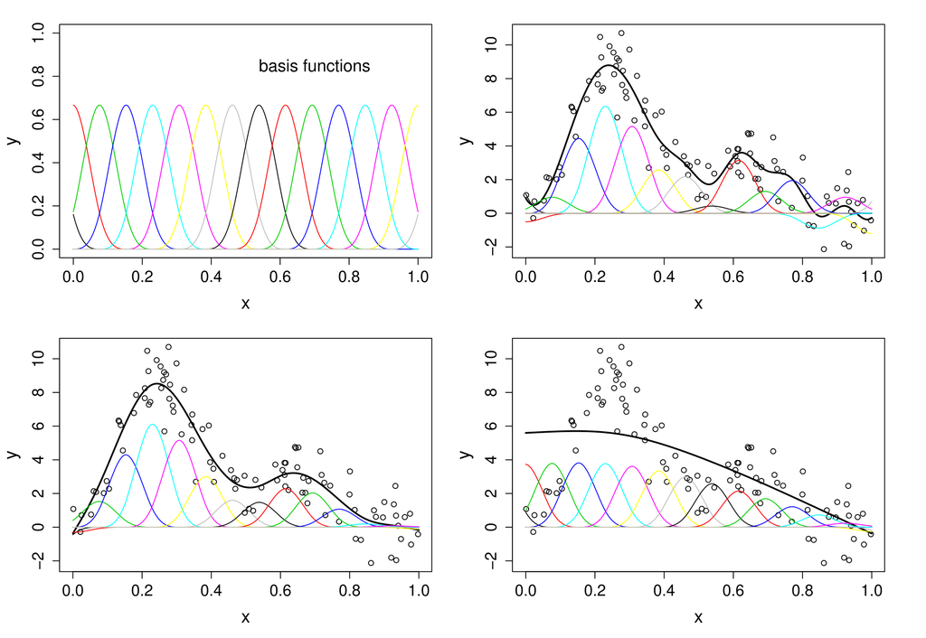

## GAMMs in R

Using the `mgcv` R library, the model for the Peak/No Peak curves is expressed as:

| Equation | R formula |
| --- | --- |
| $y_i = \beta_0 + \beta_P + f_{NP}(t_i) + f_P(t_i) + \epsilon_i$ | `y ~ Category + s(time, by = Category)` |

where $P$ indicates the Peak category, while the default (control) level is $NP$ (No Peak), and $i$ is the sample (not curve) index. The equation is omitting the indicator functions. The complete version is:
$$y_i = \beta_0 + \beta_P \cdot I(i \in P) +
f_{NP}(t_i) \cdot I(i \in NP) + f_P(t_i) \cdot I(i \in P) + \epsilon_i$$
Note the asymmetry in the conventions for the parametric and the smooth parts of the model:

- Parametric part: as in `lm()`, $\beta_0$ is the intercept, $\beta_P$ is the difference between level $P$ and the intercept
- Smooths: one for each level of the fixed factor, all zero-centered

Estimate the model with `mgcv::bam()`:

```
##
## Family: gaussian
## Link function: identity
##
## Formula:
## y ~ Category + s(time, by = Category)
##
## Parametric coefficients:
##               Estimate Std. Error t value Pr(>|t|)
## (Intercept)  0.1796755  0.0002261  794.78   <2e-16 ***
## CategoryPEAK 0.0242948  0.0003197   75.99   <2e-16 ***
## ---
## Signif. codes:  0 '***' 0.001 '**' 0.01 '*' 0.05 '.' 0.1 ' ' 1
##
## Approximate significance of smooth terms:
##                           edf Ref.df     F p-value
## s(time):CategoryNO_PEAK 8.980      9 48196  <2e-16 ***
## s(time):CategoryPEAK    8.998      9 37123  <2e-16 ***
## ---
## Signif. codes:  0 '***' 0.001 '**' 0.01 '*' 0.05 '.' 0.1 ' ' 1
##
## R-sq.(adj) =  0.975   Deviance explained = 97.5%
## fREML = -47131  Scale est. = 0.00050838  n = 19900
```

### Plotting predictions

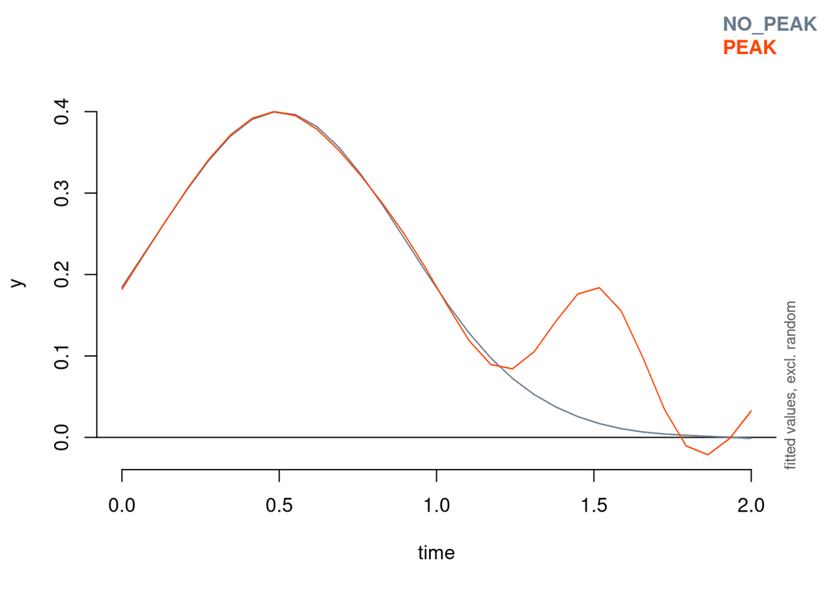

```r
plot_smooth(m2, view = "time", plot_all = "Category", print.summary = FALSE,
            col = Category.colors)
```

### Testing for significance: graphical method

A graphical way to detect statistical differences between effects is:

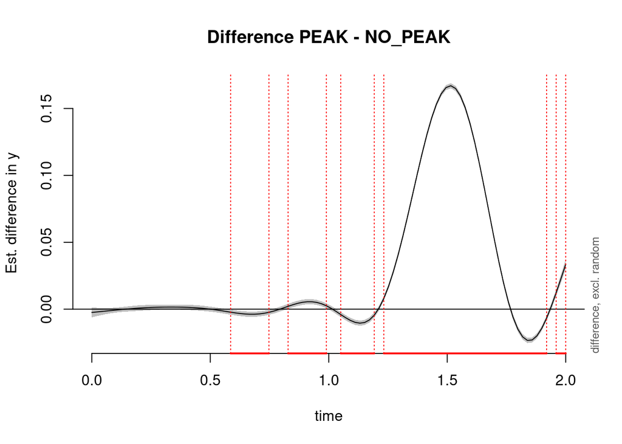

```r
plot_diff(m2, view = "time", comp = list(Category = c("PEAK", "NO_PEAK")), print.summary = FALSE)
```

### Testing for significance: binary smooths

While `emmeans` allows to test differences at specific points on the time axis (or other continuous dimensions), we need a way to assess for the significance of a smooth contrast as a whole. For the purpose, we utilise another way to specify a smooth interacting with a fixed factor with `mgcv::bam`, the so-called *binary smooths*.

A binary smooth is a smooth that represents the difference between effects (including intercepts). We use them to model the difference between two levels of a factor, or between more complex combinations of factor level interactions (more on this later). Once we are able to introduce such a term in the model, we obtain two things:

1. we can assess the statistical significance of the difference between a pair of levels of interest by reading it off the model `summary`
2. we can plot such difference and interpret it

In order to define a convenient binary smooth set up with `mgcv`, first we need to define **numeric variables with the meaning of logical variables** (yes you read it right), which represent the desired contrasts – a rather obscure convention adopted by the `mgcv` library. In our case we want to represent the difference between PEAK and NO_PEAK, with NO_PEAK as control level:

```r
curves$IsPEAK <- (curves$Category == "PEAK") * 1
```

where `* 1` is a quick way to transform the logical value inside `()` into a numeric one. The R formula and the corresponding maths form are:

| Equation | R formula |
| --- | --- |
| $y_i = \beta_0 + f_0(t_i) + b_P(t_i) \cdot I(i \in P) + \epsilon_i$ | `y ~ s(time) + s(time, by = IsPEAK)` |

where:

- $\beta_0$ is the global intercept
- $f_0(t_i)$ is the global, zero-centered smooth
- $b_P(t_i)$ is the **not zero-centered** binary smooth. It represents the total difference between PEAK and NO_PEAK

```r
m2.bin <- bam(y ~ s(time) + s(time, by = IsPEAK), data = curves)
summary(m2.bin)
```

```
##
## Family: gaussian
## Link function: identity
##
## Formula:
## y ~ s(time) + s(time, by = IsPEAK)
##
## Parametric coefficients:
##              Estimate Std. Error t value Pr(>|t|)
## (Intercept) 0.1796561  0.0002261   794.7   <2e-16 ***
## ---
## Signif. codes:  0 '***' 0.001 '**' 0.01 '*' 0.05 '.' 0.1 ' ' 1
##
## Approximate significance of smooth terms:
##                  edf Ref.df     F p-value
## s(time)        8.980      9 48195  <2e-16 ***
## s(time):IsPEAK 9.995     10  3227  <2e-16 ***
## ---
## Signif. codes:  0 '***' 0.001 '**' 0.01 '*' 0.05 '.' 0.1 ' ' 1
##
## R-sq.(adj) =  0.975   Deviance explained = 97.5%
## fREML = -47132  Scale est. = 0.00050838  n = 19900
```

| Maths | R summary |
| --- | --- |
| $\beta_0$ | `(Intercept)` |
| $f_0(t_i)$ | `s(time)` |
| $b_P(t_i)$ | `s(time):IsPEAK` |

Only now we are able to report about the significance of the difference between PEAK and NO_PEAK by reading off the `summary` output for `s(time):IsPEAK`.

Here is how the difference term $b_P(t_i)$ looks:

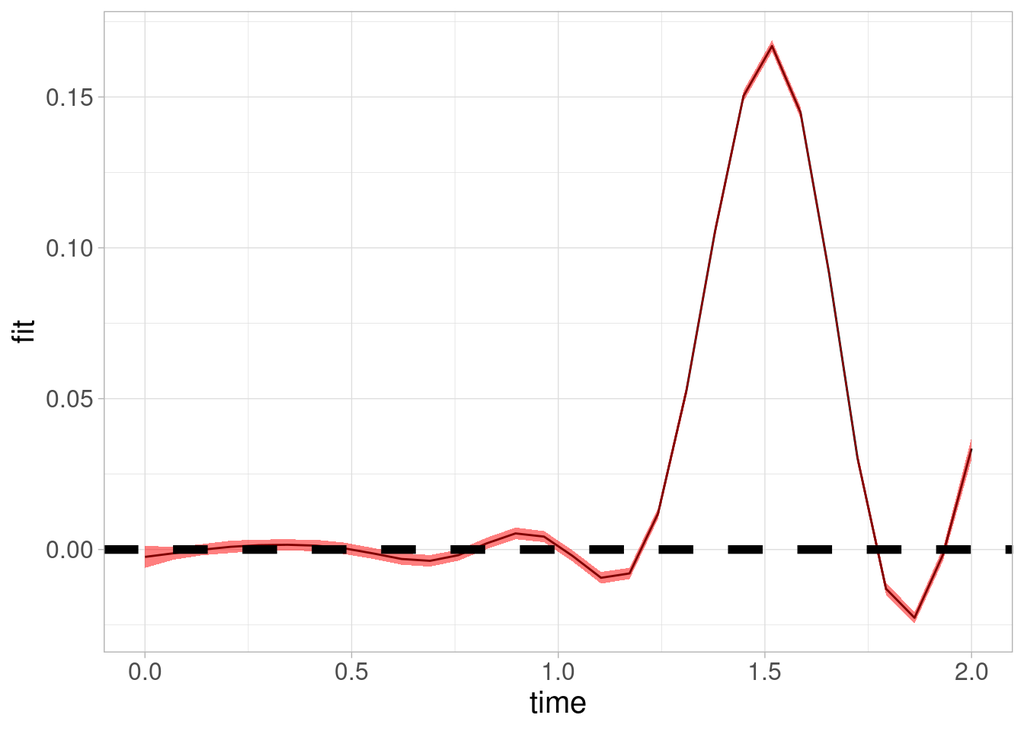

## A more complex scenario

A GAMM predicting the probability $p$ that a certain (normalised) pair of format values $F1, F2$ corresponds to a mid-close [e]. The data set is composed by mod-closed and mid-open [e].

As the data was collected from several speakers, we introduce a random *smooth* term, the generalisation of a random intercept in LMER.

| Equation | R formula |
| --- | --- |
| $logit(p) = f(F1, F2) + f_{Speaker}(F1, F2)$ | `p ~ te(F1, F2) + te(F1, F2, speaker, bs = "fs")` |

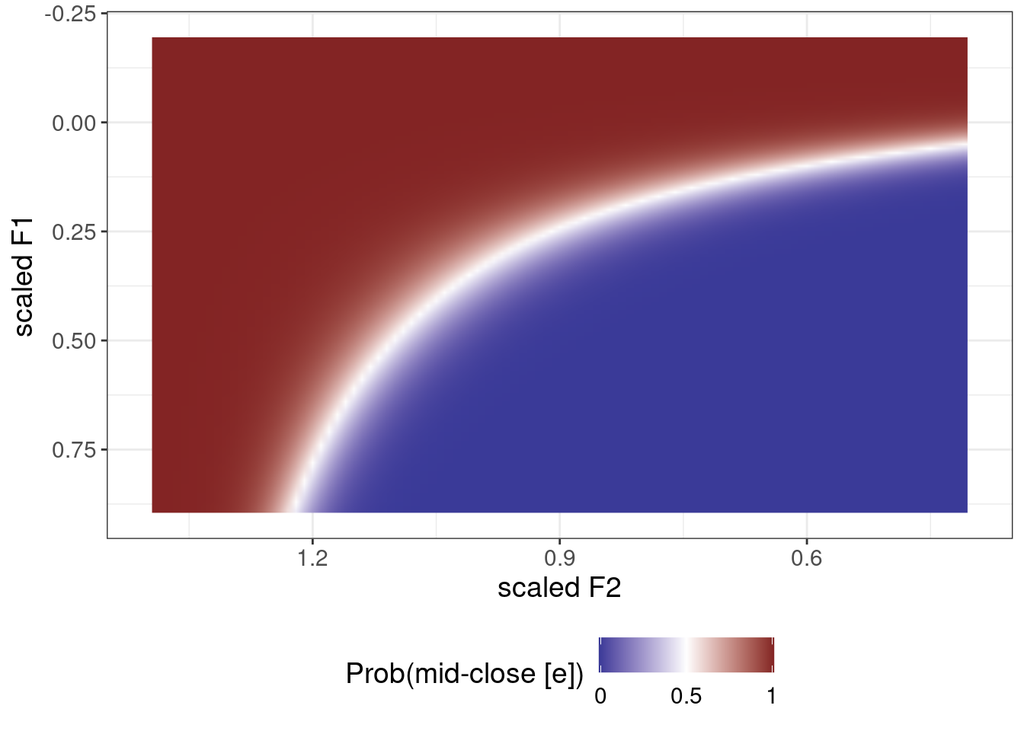

New elements:

- Two covariates (F1 and F2) instead of one (time)
- Random term (by speaker) (the first “M” in GAMM)
- logistic regression (the “G” in GAMM)

Note that each term $f$ is fairly complex, but they can only be combined by a sum (the “A” in GAMM).

## In summary: what is a GAMM?

> Curve fitting + regularisation + GLMER

### Resources

- Tutorial papers: [Martijn Wieling](http://martijnwieling.nl/files/GAM-tutorial-Wieling.pdf), [Marton Soskuthy](http://eprints.whiterose.ac.uk/113858/2/1703_05339v1.pdf)
- Online tutorials: [Joseph Roy](https://jroy042.github.io/nonlinear/), [Jacolien van Rij](http://jacolienvanrij.com/Tutorials/GAMM.html), [Peter Laurinec](https://petolau.github.io/Analyzing-double-seasonal-time-series-with-GAM-in-R/), [Noam Ross](https://noamross.github.io/gams-in-r-course/), [Michael Clark](https://m-clark.github.io/generalized-additive-models/)